# MIDI-MT - Модуль управления выполненяемых «Скриптов»

MIDI-MT Документация на Русском языке

## Модуль управления выполнением пользовательских сценариев

- Назначение сценариев в MIDI-MT
- Сценарии в группах «Аудио Микшер» и «MIDI контроль»
- Сценарии в группах «Управления устройствами Умного Дома» и «Управление Освещением»
- Настройки модуля управления сценариями
- Конфигурационный файл
- Краткие сведения о основных характеристиках языка ChaiScript
  - ChaiScript - поддерживаемые типы
  - ChaiScript - документация и примеры
- ChaiScript - отладка с помощью DebugView
- Отладка при написании собственных сценариев
- Специфические объекты MIDI-MT API в сценариях

[output not shown]

#### Назначение сценариев в MIDI-MT

Вы можете использовать собственные сценарии для автоматизации процессов управления в различных группах. Пакетное управление с помощью выполняемых скриптов может расширить ваши возможности, например:

- применение заранее запланированной схемы уровней на нескольких регуляторах,
- решение задач одновременной, плавной регулировки уровней на многих регуляторах,
- одновременное включение или выключение множества источников,
- различные световые эффекты и схемы, применяемые нажатием одной кнопки,
- выполнение последовательности команд для продуктов `Adobe`

Скриптовым ядром является `ChaiScript`, язык сценариев с открытым исходным кодом, созданный Джейсоном Тернером. Синтаксис скриптов `ChaiScript` почти идентичен `TypeScript`, `JavaScript` и фактически укладываться в стандарт `ECMASCRIPT`, с небольшими дополнениями. Ниже будут приведены основные особенности этого языка сценариев.

#### Группы «Аудио Микшер» и «MIDI контроль»

Скрипты можно рассматривать как `макросы` в примении к группе «**Аудио Микшер**» или к группе «**MIDI контроля**» для управления продуктами `Adobe`, как `Premiere Pro`, `After Effects`, `Audition` и так далее. Последовательный нбор команд, прописанных в скрипте, можно выполнить нажатием одной кнопки. Это не только экономит время, но и позволяет задействовать меньшее количество физических кнопок, при сохранении той же функциональности.

#### Группы «Управления устройствами Умного Дома» и «Управление Освещением»

Скрипты можно использовать для создания как `сценариев управления` для группы «**Умного Дома**», так и для создания собственных уникальных световых эффектов и решений для групп «**Управления Освещением**» и «**Умного Дома**».

### Настройки модуля «Управления Сценариями»

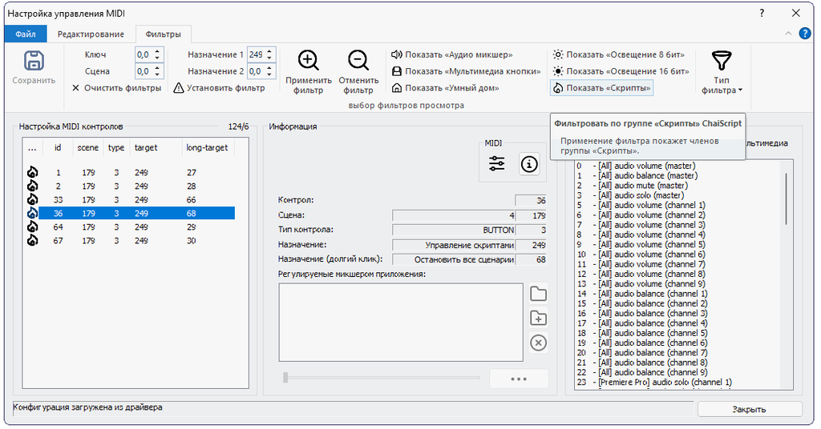

- В списке «**Доступные скрипты**» отображаются все доступные сценарии в выбранном каталоге. Файлы скриптов должны иметь расширение `.mmts`. Для каждого файла сценария, отображается его размер и время последней модификации. Обратите внимание, время модификации устанавливается на текущее время при старте программы. Эти изменения не затрагивают реальных файлов на диске.
- Выбор «**Директория скриптов**» позволяет выбрать путь, по которому находятся выполняемые сценарии.
- Опция «**Следить за изменениями в директории скриптов**» включает отслеживание изменений файлов сценариев в выбранном каталоге. В случае изменения, добавления или удаления одного из сценариев, происходит автоматическая перезагрузка списка сценариев.
- Опция «**Режим отладки**» позволяет перенаправить вывод скрита из лог файла, на специализированную программу, например DebugView или [Visual Studio Code](https://github.com/microsoft/vscode).
- Опции «**Не использовать … библиотеки**» позволяет отключать неиспользуемые вами библиотеки.

Максимальное количество вызываемых сценариев в настройках конфигурации ограничено числом `27`. Ограничений на одновременный запуск сценариев не предусмотрено, но оно также не может превышать значение `27`. Повторный вызов сценария, приводит к его завершению, если он в этот момент был запущен. Каждый сценарий может быть активным только в одном экземпляре.

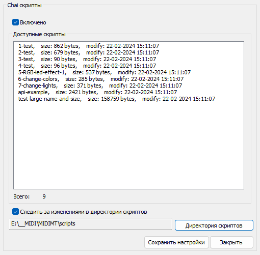

Для разработки и тестов сценариев, в дистрибутиве прилагается утилита `MMTScriptTester.exe`. Вы можете использовать её для отладки при написании собственных сценариев. Функция отслеживания изменений в каталоге сценариев также работает в `MMTScript Tester`, скпипты в случае изменения перезагружаются автоматически. Если изменения произошли в момент выполнения любого сценария, то изменения откладываются до окончания его работы.

#### Конфигурационный файл

Настройки в конфигурационном файле, выглядят следующим образом:

```yaml
{
    ...
    "vmscript": {
        "enable": true,
        "watch": true,
        "debug": false,
        "stringlib": true,
        "wstringlib": true,
        "matchlib": true,
        "directory": "C:\MIDI-MT\scripts",
        "scripts": [
        ]
    },
    ...
}
```

#### Краткие сведения о основных характеристиках языка ChaiScript

- Переменные не имеют типа до тех пор, пока им сначала не будет присвоено значение.
- Конструкции типа if, else, for и while принимают только блоки, заключённые в `{ ... };`.
- Операторы инкремента или декремента, только перед переменной `++value`.
- Ключевые слова: `attr, auto, break, case, catch, class, continue, def, default, else, elseif, else if, finally, for, global, if, return, switch, try, var, while`.
- Операторы: `? || && | ^ & == != < <= > >= << >> + - * / % ++ -- ! ~`.
- Глобальные идентификаторы: `Nan, Infinity, false, true, __CLASS__, __FILE__ , __FUNC__, __LINE__`.
- Суффиксы арифметических типов: `f, ul, u, d` и т. д.
- Переменные: `auto, var`.
- Функции: всегда начинаются с идентификатора `def` - `def my_function() { ... }`.
- Классы: есть, аналогично `C++`, подробнее в оригинальной документации.
- Целочисленные литералы как в C++. Поддерживаются десятичные бинарные, октальные и шестнадцатеричные целые литералы.
- Числа с плавающей точкой как в C++, но шестнадцатеричные литералы с плавающей точкой не поддерживаются.
- Строчные литералы стандартно заключаются в двойные кавычки, также, они могут содержать интерполяции, которые заключены в `${ ... }`.
- Комментарии: `//... /* ... */ #`.
- Специфические объекты MIDI-MT API в сценариях.

###### поддерживаемые типы:

- **Boolean**: `bool`.
- **Integers**: `int, long, unsigned_int, unsigned_long, long_long, unsigned_long_long, size_t, int8_t, int16_t, int32_t, int64_t, uint8_t, uint16_t, uint32_t, uint64_t`.
- **Floating points**: `double, long_double, float`.
- **Characters**: `char, wchar_t, char16_t, char32_t`.
- **Strings**: `string` (`C++ std::string`).
- **Aggregates**: `Vector, Map, Pair`.
- **Async**: `promise, future`.

#### DebugView

`DebugView` — это приложение, которое позволяет отслеживать выходные данные отладки в локальной системе.  
Он может отображать выходные данные отладки приложений, а также не требует изменять приложения для использования нестандартной отладочной выходной API.  
`DebugView` осуществляет перехват и отображение выходных данных отладки. Автор Марк Руссинович, [sysinternals](https://learn.microsoft.com/ru-ru/sysinternals/downloads/debugview).

#### документация и примеры ChaiScript

1. Узнать больше в [документации и примерах](https://chaiscript.com/examples.html#ChaiScript_Language_Examples) на сайте `ChaiScript`.
2. Посмотреть больше [примеров кода](https://github.com/ChaiScript/ChaiScript/tree/master/unittests) `ChaiScript`.
3. [Справочник по языку](https://github.com/ChaiScript/ChaiScript/blob/develop/cheatsheet.md#language-reference) `ChaiScript`.
4. Начало работы с `ChaiScript`:
   - [PDF](https://github.com/ClaudiaCoord/MIDI-EasyControl-to-Mackie-translator-for-Premiere-Pro/tree/main/docs/API/script/Chaiscript-Overview-and-Tutorial-RU.pdf) | [сайт](https://drolliblog.wordpress.com/2017/12/22/chaiscript-overview-and-tutorial/) часть 1 - Обзор и учебные пособия,
   - [PDF](https://github.com/ClaudiaCoord/MIDI-EasyControl-to-Mackie-translator-for-Premiere-Pro/tree/main/docs/API/script/Chaiscript-Overview-and-Tutorial-Additional-RU.pdf) | [сайт](https://drolliblog.wordpress.com/2020/08/04/chaiscript-additional-topics/) часть 2 - Обзор и дополнительные учебные пособия,
   - [сайт](https://codedocs.xyz/ChaiScript/ChaiScript/LangGettingStarted.html) часть 3 - Как начать.
5. Специфические объекты MIDI-MT API в сценариях.
6. Пример [MIDI-MT API](https://github.com/ClaudiaCoord/MIDI-EasyControl-to-Mackie-translator-for-Premiere-Pro/tree/main/docs/API/script/example/example-api.mmts).
7. Примеры управления **RGB LED**:
   - [пример RGB-led эффекта](https://github.com/ClaudiaCoord/MIDI-EasyControl-to-Mackie-translator-for-Premiere-Pro/tree/main/docs/API/script/example/example-RGB-led-effect-1.mmts),
   - [изменение цвета](https://github.com/ClaudiaCoord/MIDI-EasyControl-to-Mackie-translator-for-Premiere-Pro/tree/main/docs/API/script/example/example-change-HSV-color-constant.mmts),
   - [изменение произвольного цвета](https://github.com/ClaudiaCoord/MIDI-EasyControl-to-Mackie-translator-for-Premiere-Pro/tree/main/docs/API/script/example/example-change-HSV-color.mmts),
   - [изменение яркости](https://github.com/ClaudiaCoord/MIDI-EasyControl-to-Mackie-translator-for-Premiere-Pro/tree/main/docs/API/script/example/example-change-HSV-brightness.mmts),
   - [изменение насыщенности](https://github.com/ClaudiaCoord/MIDI-EasyControl-to-Mackie-translator-for-Premiere-Pro/tree/main/docs/API/script/example/example-change-HSV-saturation.mmts).
8. Прочие примеры:
   - [пример использования «макроса»](https://github.com/ClaudiaCoord/MIDI-EasyControl-to-Mackie-translator-for-Premiere-Pro/tree/main/docs/API/script/example/example-macro-using.mmts),
   - [пример получение списка контролов из текущей конфигурации](https://github.com/ClaudiaCoord/MIDI-EasyControl-to-Mackie-translator-for-Premiere-Pro/tree/main/docs/API/script/example/example-units-list.mmts).
9. Полезные дополнения:
   - [ChaiScript language support for Notepad++](https://github.com/ChaiScript/npp-chaiscript),
   - [VsCode ChaiScript syntax](https://github.com/codehz/vscode-chaiscript-syntax),
   - [TypeScript to Chaiscript transpiler](https://github.com/Alia5/TSChai),
   - скачать `DebugView` [x64](https://live.sysinternals.com/dbgview64.exe) | [x32](https://live.sysinternals.com/Dbgview.exe) | [ZIP](https://download.sysinternals.com/files/DebugView.zip) от [sysinternals](https://learn.microsoft.com/ru-ru/sysinternals/).